# Lecture Notes for Ch 2 of MSWR: Exploratory Data Analysis

Dr. Hasthika Rupasinghe

Jan 31, 2019 at 01:24:00 PM

# 1 Basic Plots

We have already discussed the basic graphs last week!

# 2 Numerical Summaries

## 2.1 Center

**Mean**

If $x_1, x_2,...,x_n$ are $n$ data values then the mean is:

$$\bar{x} = \dfrac{1}{n} \sum_{i=1}^{n} x_i$$

Example: Find the mean of 2, 15, 3, 8, 12, 5.

```r
data <- c(2, 15, 3, 8, 12, 5)
data1 <- c(2, 15, 3, 8, 12, 500)
mean(data)
```

```
## [1] 7.5
```

```r
mean(data1)
```

```
## [1] 90
```

**Median**

Median is the middle value of a sorted data set. Usually works well with outliers and when the distribution is skewed.

Example: Find the median of 2, 15, 3, 8, 12, 5.

```r
data <- c(2, 15, 3, 8, 12, 5)
data1 <- c(2, 15, 3, 8, 12, 500)
median(data)
```

```
## [1] 6.5
```

```r
median(data1)
```

[output not shown]

**Trimmed Mean** (25% Trimmed Mean)

Here for example you sort the data, omit 25% of the observations on each end, and then take the mean of the remaining middle 50% of the observations. Usually works well with outliers.

Example: Find the 25% Trimmed Mean of 2, 15, 3, 8, 12, 5.

```r
data <- c(2, 15, 3, 8, 12, 5)
data1 <- c(2, 15, 3, 8, 12, 500)

mean1 <- mean(data, trim = 0.25)
mean2 <- mean(data1, trim = 0.25)
mean1
```

```
## [1] 7
```

```r
mean2
```

[output not shown]

## 2.2 Spread

Following are the common measures of the spread;

**Range**

Range is the difference between the largest and the smallest values. Range is sensitive to outliers.

**IQR**

Range is the difference between the third and the first quartiles (75th and the 25th percentiles). IQR is NOT sensitive to outliers.

**Standard deviation**

If $x_1, x_2,...,x_n$ are $n$ data values then the Standard deviation is:

$$s = \sqrt{\dfrac{1}{n-1}\sum_{i=1}^n (x_i - \bar{x})^2}$$

Example: Find the Range, IQR and the Standard deviation of 2, 15, 3, 8, 12, 5.

```r
data <- c(2, 15, 3, 8, 12, 5)

range(data)
```

```
## [1]  2 15
```

```r
IQR(data)
```

```
## [1] 7.5
```

```r
sd(data)
```

```
## [1] 5.167204
```

## 2.3 Shape

### 2.3.1 Five number summary

In this class we use the `five number summary` to describe the shape of a data set.

`five number summary`: The minimum, first quartile, median, third quartile, and the maximum.

Example: Consider the 15 numbers 9,10,11,11,12,14,16,17,19,21,25,31,32,41,61. Find the five number summary.

```r
fiveNum <- c(9,10,11,11,12,14,16,17,19,21,25,31,32,41,61)

summary(fiveNum)
```

```
##    Min. 1st Qu.  Median    Mean 3rd Qu.    Max.
##     9.0    11.5    17.0    22.0    28.0    61.0
```

Five num summary is

1. min = 9
2. $Q_1$ = 11.5
3. Median = 17
4. $Q_3$ = 28
5. max = 61

### 2.3.2 Boxplots

A boxplot is a type of graph that can be used to visualize the five-number summary.

Create a boxplot for the following 21 data values.

5, 6, 6, 8, 9, 11, 11, 14, 17, 17, 19, 20, 21, 21, 22, 23, 24, 32, 40, 43, 49.

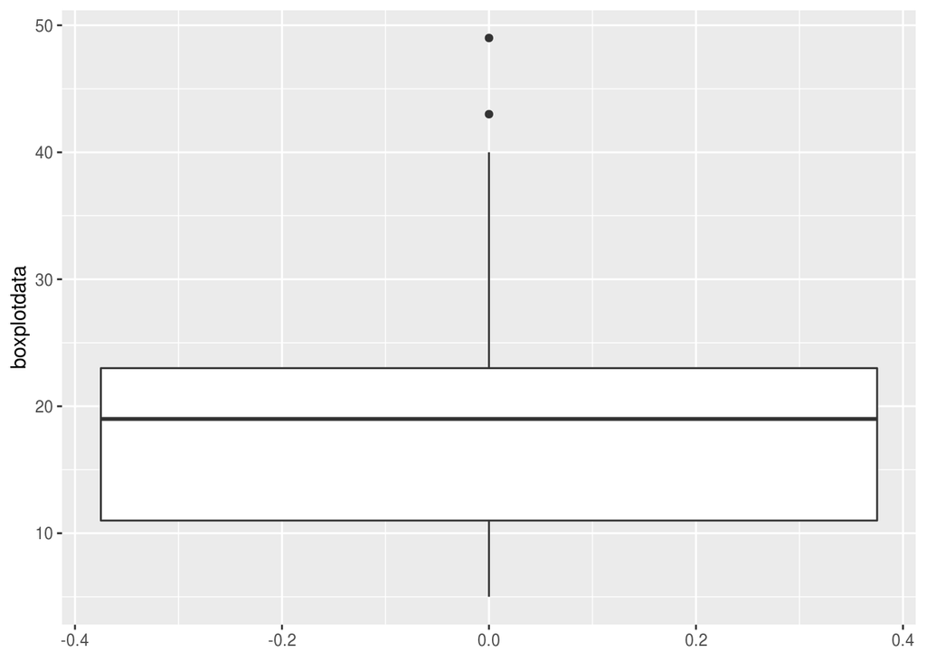

```r
library(ggplot2)

boxplotdata <- c(5, 6, 6, 8, 9, 11, 11, 14, 17, 17, 19, 20, 21, 21, 22, 23, 24, 32, 40, 43, 49)

boxplotdata <- data.frame(boxplotdata)

ggplot(data = boxplotdata, mapping = aes(y = boxplotdata)) +
  geom_boxplot()
```

**Notes about a boxplot:**

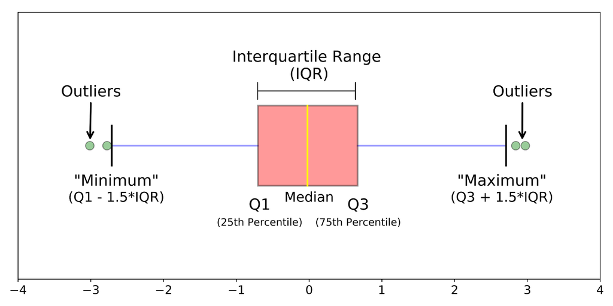

Boxplot

### 2.3.3 Normal Distribution

The normal distribution is the most important and most widely used distribution in statistics. It is sometimes called the “bell curve” because the normal distribution is bell shaped and symmetric. We would “like” data to be normally distributed.

Here is an example: Check whether the data below are normal distributed.

**1. Create a histogram and check if it is “Normal” enough!**

```r
library(ggplot2)


data <- c(11.62, 15.92, 12.40, 14.40, 10.28, 13.15, 11.22,  7.35, 16.45,  5.37, 10.25, 12.41, 11.43,  8.00, 11.90, 17.86,  7.59, 11.88, 14.54, 14.44, 10.29,  5.47,  8.20, 10.56, 11.18)

MyDataFrame <- data.frame(data)
MyDataFrame
```

```
##     data
## 1  11.62
## 2  15.92
## 3  12.40
## 4  14.40
## 5  10.28
## 6  13.15
## 7  11.22
## 8   7.35
## 9  16.45
## 10  5.37
## 11 10.25
## 12 12.41
## 13 11.43
## 14  8.00
## 15 11.90
## 16 17.86
## 17  7.59
## 18 11.88
## 19 14.54
## 20 14.44
## 21 10.29
## 22  5.47
## 23  8.20
## 24 10.56
## 25 11.18
```

```r
mean(MyDataFrame$data)
```

```
## [1] 11.3664
```

```r
sd(MyDataFrame$data)
```

```
## [1] 3.22871
```

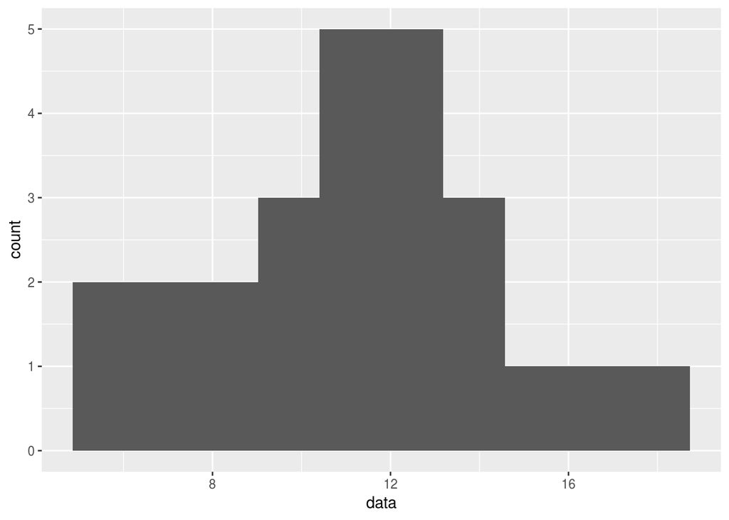

```r
ggplot(data = MyDataFrame, aes(x=data)) + geom_histogram(bins = 10)
```

2. Check using a Normal quantile plot (QQ plot) - Preferred way!

If the plotted points follow the identity line, then your data is Normal.

```r
library(ggplot2)


data <- c(11.62, 15.92, 12.40, 14.40, 10.28, 13.15, 11.22,  7.35, 16.45,  5.37, 10.25, 12.41, 11.43,  8.00, 11.90, 17.86,  7.59, 11.88, 14.54, 14.44, 10.29,  5.47,  8.20, 10.56, 11.18)

MyDataFrame <- data.frame(data)
MyDataFrame
```

```
##     data
## 1  11.62
## 2  15.92
## 3  12.40
## 4  14.40
## 5  10.28
## 6  13.15
## 7  11.22
## 8   7.35
## 9  16.45
## 10  5.37
## 11 10.25
## 12 12.41
## 13 11.43
## 14  8.00
## 15 11.90
## 16 17.86
## 17  7.59
## 18 11.88
## 19 14.54
## 20 14.44
## 21 10.29
## 22  5.47
## 23  8.20
## 24 10.56
## 25 11.18
```

```r
mean(MyDataFrame$data)
```

```
## [1] 11.3664
```

```r
sd(MyDataFrame$data)
```

```
## [1] 3.22871
```

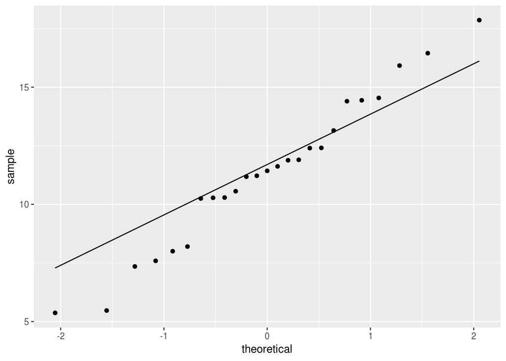

```r
ggplot(data = MyDataFrame, aes(sample = data)) + geom_qq() + geom_qq_line()
```

Example: Exercise 2.4

Import the `flight delays` case study in Section 1.1.

```r
library(resampledata) # dataset for MSWR book is in this library
```

```r
library(ggplot2)
library(dplyr)
data(FlightDelays)
```

1. *Create a table and a bar chart of the departure times (`DepartTime`)*

```r
head(FlightDelays)
```

```
##   ID Carrier FlightNo Destination DepartTime Day Month FlightLength Delay
## 1  1      UA      403         DEN      4-8am Fri   May          281    -1
## 2  2      UA      405         DEN     8-Noon Fri   May          277   102
## 3  3      UA      409         DEN      4-8pm Fri   May          279     4
## 4  4      UA      511         ORD     8-Noon Fri   May          158    -2
## 5  5      UA      667         ORD      4-8am Fri   May          143    -3
## 6  6      UA      669         ORD      4-8am Fri   May          150     0
##   Delayed30
## 1        No
## 2       Yes
## 3        No
## 4        No
## 5        No
## 6        No
```

```r
glimpse(FlightDelays)
```

```
## Observations: 4,029
## Variables: 10
## $ ID           <int> 1, 2, 3, 4, 5, 6, 7, 8, 9, 10, 11, 12, 13, 14, 15, …
## $ Carrier      <fct> UA, UA, UA, UA, UA, UA, UA, UA, UA, UA, UA, UA, UA,…
## $ FlightNo     <int> 403, 405, 409, 511, 667, 669, 673, 677, 679, 681, 6…
## $ Destination  <fct> DEN, DEN, DEN, ORD, ORD, ORD, ORD, ORD, ORD, ORD, O…
## $ DepartTime   <fct> 4-8am, 8-Noon, 4-8pm, 8-Noon, 4-8am, 4-8am, 8-Noon,…
## $ Day          <fct> Fri, Fri, Fri, Fri, Fri, Fri, Fri, Fri, Fri, Fri, F…
## $ Month        <fct> May, May, May, May, May, May, May, May, May, May, M…
## $ FlightLength <int> 281, 277, 279, 158, 143, 150, 158, 160, 160, 163, 1…
## $ Delay        <int> -1, 102, 4, -2, -3, 0, -5, 0, 10, 60, 0, 32, 0, 44,…
## $ Delayed30    <fct> No, Yes, No, No, No, No, No, No, No, Yes, No, Yes, …
```

```r
table(FlightDelays$DepartTime)
```

```
##
##    4-8am   8-Noon Noon-4pm    4-8pm    8-Mid
##      699     1053     1048      972      257
```

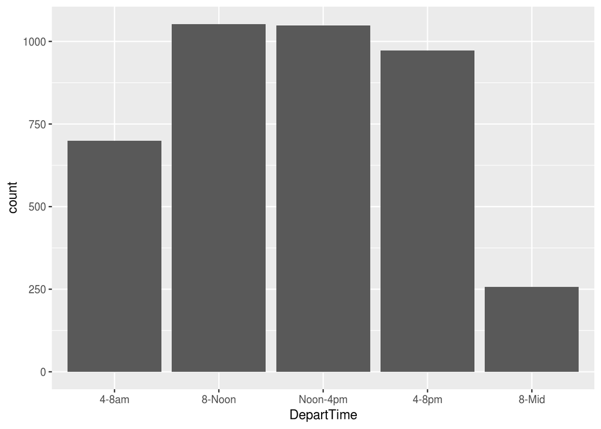

```r
ggplot(data = FlightDelays, mapping = aes(x = DepartTime)) +
  geom_bar()
```

2. *Create a contingency table of the variables `Day` and `Delayed30`. For each day, what is the proportion of flights delayed at least 30 min.*

```r
table(FlightDelays$Day, FlightDelays$Delayed30)
```

```
##
##        No Yes
##   Sun 507  44
##   Mon 569  61
##   Tue 535  93
##   Wed 488  76
##   Thu 434 132
##   Fri 493 144
##   Sat 406  47
```

Here we use Ch 5: Data Wrangling via dplyr, of MD.

Note:

The `%>%` operator allows us to go from one step in `dplyr` to the next easily so we can, for example:

- filter our data frame to only focus on a few rows then
- group_by another variable to create groups then
- summarize this grouped data to calculate the mean (for example) for each level of the group.

```r
day_delayed30 <- FlightDelays %>%
  group_by(Day) %>%
  summarize(proportion= sum(Delayed30=="Yes")/sum(Delayed30=="Yes"|Delayed30=="No"))

day_delayed30
```

```
## # A tibble: 7 x 2
##   Day   proportion
##   <fct>      <dbl>
## 1 Sun       0.0799
## 2 Mon       0.0968
## 3 Tue       0.148
## 4 Wed       0.135
## 5 Thu       0.233
## 6 Fri       0.226
## 7 Sat       0.104
```

```r
library(knitr) #for printing html-friendly tables.


day_delayed30 <- FlightDelays %>%
  group_by(Day) %>%
  summarize(proportion= sum(Delayed30=="Yes")/sum(Delayed30=="Yes"|Delayed30=="No"))

kable(day_delayed30)
```

| Day | proportion |
| --- | --- |
| Sun | 0.0798548 |
| Mon | 0.0968254 |
| Tue | 0.1480892 |
| Wed | 0.1347518 |
| Thu | 0.2332155 |
| Fri | 0.2260597 |
| Sat | 0.1037528 |

3. *Create side by side boxplots of the lenghts of the flights, grouped by whether or not the flight was delayed at least 30 min.*

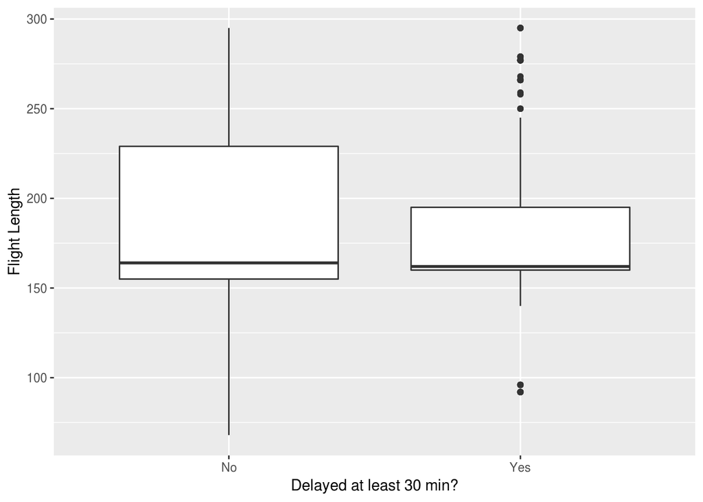

```r
ggplot(data = FlightDelays, mapping = aes(x = factor(Delayed30), y = FlightLength)) +
  geom_boxplot() +
    labs(x = "Delayed at least 30 min?", y ="Flight Length")
```

4. *Do you think that there is a relationship between the lenght of a flight and whether or not the depature is delayed by at least 30 min?*

Exercise 2.5:

```r
data("GSS2002")
str(GSS2002)
```

```
## 'data.frame':    2765 obs. of  21 variables:
##  $ ID           : int  1 2 3 4 5 6 7 8 9 10 ...
##  $ Region       : Factor w/ 7 levels "Mid-Atl","Mountain",..: 7 7 7 7 7 7 7 7 7 7 ...
##  $ Gender       : Factor w/ 2 levels "Female","Male": 1 2 1 1 2 2 1 1 2 1 ...
##  $ Race         : Factor w/ 3 levels "Black","Other",..: 3 3 3 3 3 3 3 3 3 2 ...
##  $ Education    : Factor w/ 5 levels "Left HS","HS",..: 2 4 2 1 1 2 4 2 2 2 ...
##  $ Marital      : Factor w/ 5 levels "Divorced","Married",..: 1 2 4 1 1 1 2 2 1 3 ...
##  $ Religion     : Factor w/ 13 levels "Buddhism","Catholic",..: 5 13 13 13 13 2 13 13 2 2 ...
##  $ Happy        : Factor w/ 3 levels "Not too happy",..: 2 2 NA NA NA 2 NA NA 1 NA ...
##  $ Income       : Factor w/ 24 levels "under 1000","1000-2999",..: 16 21 17 19 18 18 NA NA 20 1 ...
##  $ PolParty     : Factor w/ 8 levels "Ind","Ind, Near Dem",..: 8 5 8 2 1 3 8 1 8 3 ...
##  $ Politics     : Factor w/ 7 levels "Conservative",..: 1 1 NA NA NA 1 NA NA 1 NA ...
##  $ Marijuana    : Factor w/ 2 levels "Legal","Not legal": NA 2 NA NA NA NA NA NA 1 NA ...
##  $ DeathPenalty : Factor w/ 2 levels "Favor","Oppose": 1 1 NA NA NA 1 NA NA 1 NA ...
##  $ OwnGun       : Factor w/ 3 levels "No","Refused",..: 1 3 NA NA NA 3 NA NA 3 NA ...
##  $ GunLaw       : Factor w/ 2 levels "Favor","Oppose": 1 2 NA NA NA 2 NA NA 2 NA ...
##  $ SpendMilitary: Factor w/ 3 levels "About right",..: 2 1 NA 1 NA 2 NA 2 NA 3 ...
##  $ SpendEduc    : Factor w/ 3 levels "About right",..: 2 2 NA 2 NA 2 NA 2 NA 2 ...
##  $ SpendEnv     : Factor w/ 3 levels "About right",..: 1 1 NA 2 NA 2 NA 1 NA 2 ...
##  $ SpendSci     : Factor w/ 3 levels "About right",..: 1 1 NA 2 NA 2 NA 1 NA 2 ...
##  $ Pres00       : Factor w/ 5 levels "Bush","Didnt vote",..: 1 1 1 NA NA 1 1 1 1 NA ...
##  $ Postlife     : Factor w/ 2 levels "No","Yes": 2 2 NA NA NA 2 NA NA 2 NA ...
```

```r
table(GSS2002$DeathPenalty)
```

```
##
##  Favor Oppose
##    899    409
```

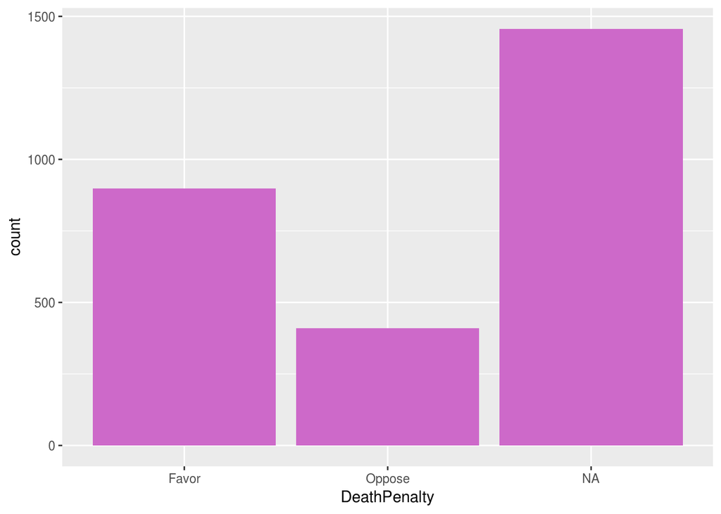

```r
ggplot(data = GSS2002, mapping = aes(x = DeathPenalty)) +
  geom_bar(fill = "orchid3")
```

```r
table(GSS2002$OwnGun)
```

```
##
##      No Refused     Yes
##     605       9     310
```

```r
summary(GSS2002$OwnGun)
```

```
##      No Refused     Yes    NA's
##     605       9     310    1841
```

```r
table(GSS2002$OwnGun, GSS2002$DeathPenalty)
```

```
##
##           Favor Oppose
##   No        375    199
##   Refused     7      2
##   Yes       243     59
```

```r
death_gun <- GSS2002 %>%
  group_by(OwnGun) %>%
  summarize(proportion_favor_death = sum(DeathPenalty=="Favor", na.rm = TRUE)/sum(DeathPenalty=="Favor"|DeathPenalty=="Oppose", na.rm = TRUE))

death_gun
```

```
## # A tibble: 4 x 2
##   OwnGun  proportion_favor_death
##   <fct>                    <dbl>
## 1 No                       0.653
## 2 Refused                  0.778
## 3 Yes                      0.805
## 4 <NA>                     0.648
```

Exercise 2.7: